# Risk Factor Analysis

## Outcome Variable

**Outcome Variable:** wast_rec90d

## Predictor Variables

**Intervention Variable:** feducyrs

**Adjustment Set:**

- arm
- W_mage
- meducyrs
- hhwealth_quart
- W_mhtcm
- W_gagebrth
- W_birthwt
- W_birthlen
- W_nrooms
- W_nchldlt5
- impfloor
- impsan
- safeh20
- delta_W_mage
- delta_meducyrs
- delta_hhwealth_quart
- delta_W_mhtcm
- delta_W_gagebrth
- delta_W_birthwt
- delta_W_birthlen
- delta_W_nrooms
- delta_W_nchldlt5
- delta_impfloor
- delta_impsan
- delta_safeh20

## Stratifying Variables

The analysis was stratified on these variable(s):

- agecat
- studyid
- country

## Data Summary

| agecat | studyid | country | feducyrs | wast_rec90d | n_cell | n |
| --- | --- | --- | --- | --- | --- | --- |
| 0-24 months | ki0047075b-MAL-ED | BANGLADESH | Low | 0 | 9 | 70 |
| 0-24 months | ki0047075b-MAL-ED | BANGLADESH | Low | 1 | 18 | 70 |
| 0-24 months | ki0047075b-MAL-ED | BANGLADESH | Medium | 0 | 10 | 70 |
| 0-24 months | ki0047075b-MAL-ED | BANGLADESH | Medium | 1 | 15 | 70 |
| 0-24 months | ki0047075b-MAL-ED | BANGLADESH | High | 0 | 6 | 70 |
| 0-24 months | ki0047075b-MAL-ED | BANGLADESH | High | 1 | 12 | 70 |
| 0-24 months | ki0047075b-MAL-ED | INDIA | Low | 0 | 16 | 103 |
| 0-24 months | ki0047075b-MAL-ED | INDIA | Low | 1 | 31 | 103 |
| 0-24 months | ki0047075b-MAL-ED | INDIA | Medium | 0 | 15 | 103 |
| 0-24 months | ki0047075b-MAL-ED | INDIA | Medium | 1 | 13 | 103 |
| 0-24 months | ki0047075b-MAL-ED | INDIA | High | 0 | 7 | 103 |
| 0-24 months | ki0047075b-MAL-ED | INDIA | High | 1 | 21 | 103 |
| 0-24 months | ki0047075b-MAL-ED | NEPAL | Low | 0 | 2 | 34 |
| 0-24 months | ki0047075b-MAL-ED | NEPAL | Low | 1 | 9 | 34 |
| 0-24 months | ki0047075b-MAL-ED | NEPAL | Medium | 0 | 4 | 34 |
| 0-24 months | ki0047075b-MAL-ED | NEPAL | Medium | 1 | 8 | 34 |
| 0-24 months | ki0047075b-MAL-ED | NEPAL | High | 0 | 2 | 34 |
| 0-24 months | ki0047075b-MAL-ED | NEPAL | High | 1 | 9 | 34 |
| 0-24 months | ki0047075b-MAL-ED | PERU | Low | 0 | 1 | 25 |
| 0-24 months | ki0047075b-MAL-ED | PERU | Low | 1 | 3 | 25 |
| 0-24 months | ki0047075b-MAL-ED | PERU | Medium | 0 | 1 | 25 |
| 0-24 months | ki0047075b-MAL-ED | PERU | Medium | 1 | 10 | 25 |
| 0-24 months | ki0047075b-MAL-ED | PERU | High | 0 | 2 | 25 |
| 0-24 months | ki0047075b-MAL-ED | PERU | High | 1 | 8 | 25 |
| 0-24 months | ki0047075b-MAL-ED | SOUTH AFRICA | Low | 0 | 3 | 28 |
| 0-24 months | ki0047075b-MAL-ED | SOUTH AFRICA | Low | 1 | 8 | 28 |
| 0-24 months | ki0047075b-MAL-ED | SOUTH AFRICA | Medium | 0 | 1 | 28 |
| 0-24 months | ki0047075b-MAL-ED | SOUTH AFRICA | Medium | 1 | 7 | 28 |
| 0-24 months | ki0047075b-MAL-ED | SOUTH AFRICA | High | 0 | 2 | 28 |
| 0-24 months | ki0047075b-MAL-ED | SOUTH AFRICA | High | 1 | 7 | 28 |

[output cut: 330 more lines]

The following strata were considered:

- agecat: 0-24 months, studyid: ki0047075b-MAL-ED, country: BANGLADESH
- agecat: 0-24 months, studyid: ki0047075b-MAL-ED, country: INDIA
- agecat: 0-24 months, studyid: ki0047075b-MAL-ED, country: NEPAL
- agecat: 0-24 months, studyid: ki0047075b-MAL-ED, country: PERU
- agecat: 0-24 months, studyid: ki0047075b-MAL-ED, country: SOUTH AFRICA
- agecat: 0-24 months, studyid: ki0047075b-MAL-ED, country: TANZANIA, UNITED REPUBLIC OF
- agecat: 0-24 months, studyid: ki1000304b-SAS-CompFeed, country: INDIA
- agecat: 0-24 months, studyid: ki1000304b-SAS-FoodSuppl, country: INDIA
- agecat: 0-24 months, studyid: ki1017093b-PROVIDE, country: BANGLADESH
- agecat: 0-24 months, studyid: ki1017093c-NIH-Crypto, country: BANGLADESH
- agecat: 0-24 months, studyid: ki1066203-TanzaniaChild2, country: TANZANIA, UNITED REPUBLIC OF
- agecat: 0-24 months, studyid: ki1113344-GMS-Nepal, country: NEPAL
- agecat: 0-24 months, studyid: ki1119695-PROBIT, country: BELARUS
- agecat: 0-24 months, studyid: ki1126311-ZVITAMBO, country: ZIMBABWE
- agecat: 0-24 months, studyid: ki1135781-COHORTS, country: GUATEMALA
- agecat: 0-24 months, studyid: ki1135781-COHORTS, country: INDIA
- agecat: 0-24 months, studyid: ki1135781-COHORTS, country: PHILIPPINES
- agecat: 0-24 months, studyid: ki1148112-LCNI-5, country: MALAWI
- agecat: 0-24 months, studyid: kiGH5241-JiVitA-3, country: BANGLADESH
- agecat: 0-24 months, studyid: kiGH5241-JiVitA-4, country: BANGLADESH
- agecat: 0-6 months, studyid: ki0047075b-MAL-ED, country: BANGLADESH
- agecat: 0-6 months, studyid: ki0047075b-MAL-ED, country: INDIA
- agecat: 0-6 months, studyid: ki0047075b-MAL-ED, country: NEPAL
- agecat: 0-6 months, studyid: ki0047075b-MAL-ED, country: PERU
- agecat: 0-6 months, studyid: ki0047075b-MAL-ED, country: SOUTH AFRICA
- agecat: 0-6 months, studyid: ki0047075b-MAL-ED, country: TANZANIA, UNITED REPUBLIC OF
- agecat: 0-6 months, studyid: ki1000304b-SAS-CompFeed, country: INDIA
- agecat: 0-6 months, studyid: ki1000304b-SAS-FoodSuppl, country: INDIA
- agecat: 0-6 months, studyid: ki1017093b-PROVIDE, country: BANGLADESH
- agecat: 0-6 months, studyid: ki1017093c-NIH-Crypto, country: BANGLADESH
- agecat: 0-6 months, studyid: ki1066203-TanzaniaChild2, country: TANZANIA, UNITED REPUBLIC OF
- agecat: 0-6 months, studyid: ki1113344-GMS-Nepal, country: NEPAL
- agecat: 0-6 months, studyid: ki1119695-PROBIT, country: BELARUS
- agecat: 0-6 months, studyid: ki1126311-ZVITAMBO, country: ZIMBABWE
- agecat: 0-6 months, studyid: ki1135781-COHORTS, country: GUATEMALA
- agecat: 0-6 months, studyid: ki1135781-COHORTS, country: INDIA
- agecat: 0-6 months, studyid: ki1135781-COHORTS, country: PHILIPPINES
- agecat: 0-6 months, studyid: ki1148112-LCNI-5, country: MALAWI
- agecat: 0-6 months, studyid: kiGH5241-JiVitA-3, country: BANGLADESH
- agecat: 0-6 months, studyid: kiGH5241-JiVitA-4, country: BANGLADESH
- agecat: 6-24 months, studyid: ki0047075b-MAL-ED, country: BANGLADESH
- agecat: 6-24 months, studyid: ki0047075b-MAL-ED, country: INDIA
- agecat: 6-24 months, studyid: ki0047075b-MAL-ED, country: NEPAL
- agecat: 6-24 months, studyid: ki0047075b-MAL-ED, country: PERU
- agecat: 6-24 months, studyid: ki0047075b-MAL-ED, country: SOUTH AFRICA
- agecat: 6-24 months, studyid: ki0047075b-MAL-ED, country: TANZANIA, UNITED REPUBLIC OF
- agecat: 6-24 months, studyid: ki1000304b-SAS-CompFeed, country: INDIA
- agecat: 6-24 months, studyid: ki1000304b-SAS-FoodSuppl, country: INDIA
- agecat: 6-24 months, studyid: ki1017093b-PROVIDE, country: BANGLADESH
- agecat: 6-24 months, studyid: ki1017093c-NIH-Crypto, country: BANGLADESH
- agecat: 6-24 months, studyid: ki1066203-TanzaniaChild2, country: TANZANIA, UNITED REPUBLIC OF
- agecat: 6-24 months, studyid: ki1113344-GMS-Nepal, country: NEPAL
- agecat: 6-24 months, studyid: ki1119695-PROBIT, country: BELARUS
- agecat: 6-24 months, studyid: ki1126311-ZVITAMBO, country: ZIMBABWE
- agecat: 6-24 months, studyid: ki1135781-COHORTS, country: GUATEMALA
- agecat: 6-24 months, studyid: ki1135781-COHORTS, country: INDIA
- agecat: 6-24 months, studyid: ki1135781-COHORTS, country: PHILIPPINES
- agecat: 6-24 months, studyid: ki1148112-LCNI-5, country: MALAWI
- agecat: 6-24 months, studyid: kiGH5241-JiVitA-3, country: BANGLADESH
- agecat: 6-24 months, studyid: kiGH5241-JiVitA-4, country: BANGLADESH

### Dropped Strata

Some strata were dropped due to rare outcomes:

- agecat: 0-24 months, studyid: ki0047075b-MAL-ED, country: NEPAL
- agecat: 0-24 months, studyid: ki0047075b-MAL-ED, country: PERU
- agecat: 0-24 months, studyid: ki0047075b-MAL-ED, country: SOUTH AFRICA
- agecat: 0-24 months, studyid: ki0047075b-MAL-ED, country: TANZANIA, UNITED REPUBLIC OF
- agecat: 0-24 months, studyid: ki1000304b-SAS-FoodSuppl, country: INDIA
- agecat: 0-24 months, studyid: ki1148112-LCNI-5, country: MALAWI
- agecat: 0-6 months, studyid: ki0047075b-MAL-ED, country: BANGLADESH
- agecat: 0-6 months, studyid: ki0047075b-MAL-ED, country: INDIA
- agecat: 0-6 months, studyid: ki0047075b-MAL-ED, country: NEPAL
- agecat: 0-6 months, studyid: ki0047075b-MAL-ED, country: PERU
- agecat: 0-6 months, studyid: ki0047075b-MAL-ED, country: SOUTH AFRICA
- agecat: 0-6 months, studyid: ki0047075b-MAL-ED, country: TANZANIA, UNITED REPUBLIC OF
- agecat: 0-6 months, studyid: ki1000304b-SAS-FoodSuppl, country: INDIA
- agecat: 0-6 months, studyid: ki1017093c-NIH-Crypto, country: BANGLADESH
- agecat: 0-6 months, studyid: ki1148112-LCNI-5, country: MALAWI
- agecat: 6-24 months, studyid: ki0047075b-MAL-ED, country: BANGLADESH
- agecat: 6-24 months, studyid: ki0047075b-MAL-ED, country: NEPAL
- agecat: 6-24 months, studyid: ki0047075b-MAL-ED, country: PERU
- agecat: 6-24 months, studyid: ki0047075b-MAL-ED, country: SOUTH AFRICA
- agecat: 6-24 months, studyid: ki0047075b-MAL-ED, country: TANZANIA, UNITED REPUBLIC OF
- agecat: 6-24 months, studyid: ki1000304b-SAS-FoodSuppl, country: INDIA
- agecat: 6-24 months, studyid: ki1017093c-NIH-Crypto, country: BANGLADESH
- agecat: 6-24 months, studyid: ki1126311-ZVITAMBO, country: ZIMBABWE
- agecat: 6-24 months, studyid: ki1135781-COHORTS, country: GUATEMALA
- agecat: 6-24 months, studyid: ki1135781-COHORTS, country: INDIA
- agecat: 6-24 months, studyid: ki1148112-LCNI-5, country: MALAWI
- agecat: 6-24 months, studyid: kiGH5241-JiVitA-3, country: BANGLADESH

## Methods Detail

We’re interested in the causal parameters $E[Y_a]$ for all values of $a \in \mathcal{A}$. These parameters represent the mean outcome if, possibly contrary to fact, we intervened to set all units to have $A=a$. Under the randomization and positivity assumptions, these are identified by the statistical parameters $\psi_a=E_W[E_{Y|A,W}(Y|A=a,W)]$. In addition, we’re interested in the mean of $Y$, $E[Y]$ under no intervention (the observed mean). We will estimate these parameters by using SuperLearner to fit the relevant likelihood factors – $E_{Y|A,W}(Y|A=a,W)$ and $p(A=a|W)$, and then updating our likelihood fit using a joint TMLE.

For unadjusted analyses ($W=\{\}$), initial likelihoods were estimated using Lrnr_glm to estimate the simple $E(Y|A)$ and Lrnr_mean to estimate $p(A)$. For adjusted analyses, a small library containing Lrnr_glmnet, Lrnr_xgboost, and Lrnr_mean was used.

Having estimated these parameters, we will then use the delta method to estimate relative risks and attributable risks relative to a prespecified baseline level of $A$.

# Results Detail

## Results Plots

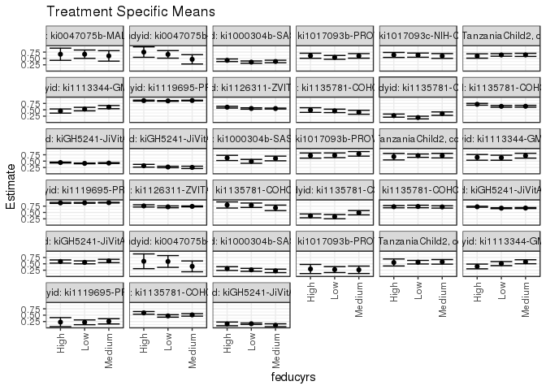

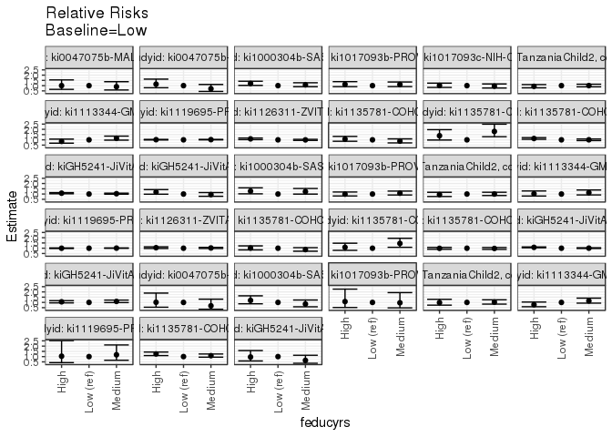

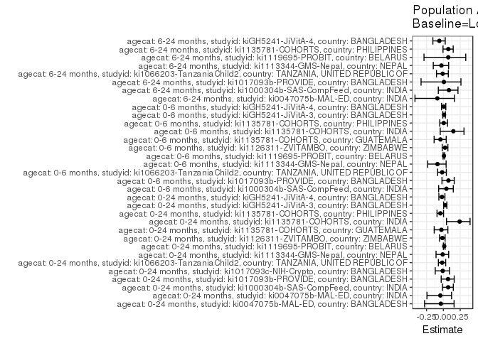

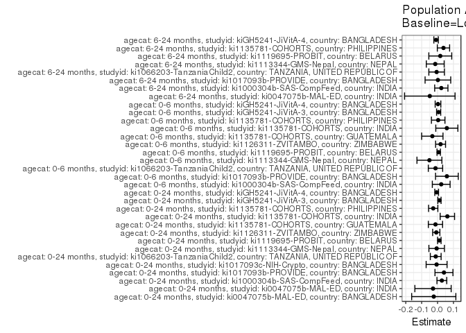

## Results Table

### Parameter: TSM

| agecat | studyid | country | intervention_level | baseline_level | estimate | ci_lower | ci_upper |
| --- | --- | --- | --- | --- | --- | --- | --- |
| 0-24 months | ki0047075b-MAL-ED | BANGLADESH | Low | NA | 0.6666667 | 0.5025048 | 0.8308285 |
| 0-24 months | ki0047075b-MAL-ED | BANGLADESH | Medium | NA | 0.6000000 | 0.3938977 | 0.8061023 |
| 0-24 months | ki0047075b-MAL-ED | BANGLADESH | High | NA | 0.6666667 | 0.4269601 | 0.9063732 |
| 0-24 months | ki0047075b-MAL-ED | INDIA | Low | NA | 0.6595745 | 0.5113855 | 0.8077634 |
| 0-24 months | ki0047075b-MAL-ED | INDIA | Medium | NA | 0.4642857 | 0.2805212 | 0.6480502 |
| 0-24 months | ki0047075b-MAL-ED | INDIA | High | NA | 0.7500000 | 0.5458782 | 0.9541218 |
| 0-24 months | ki1000304b-SAS-CompFeed | INDIA | Low | NA | 0.3551742 | 0.3106750 | 0.3996734 |
| 0-24 months | ki1000304b-SAS-CompFeed | INDIA | Medium | NA | 0.3809212 | 0.3308543 | 0.4309882 |
| 0-24 months | ki1000304b-SAS-CompFeed | INDIA | High | NA | 0.4280544 | 0.3769610 | 0.4791477 |
| 0-24 months | ki1017093b-PROVIDE | BANGLADESH | Low | NA | 0.5426940 | 0.4664478 | 0.6189402 |
| 0-24 months | ki1017093b-PROVIDE | BANGLADESH | Medium | NA | 0.6006099 | 0.5106437 | 0.6905761 |
| 0-24 months | ki1017093b-PROVIDE | BANGLADESH | High | NA | 0.6067733 | 0.5076829 | 0.7058637 |
| 0-24 months | ki1017093c-NIH-Crypto | BANGLADESH | Low | NA | 0.6298143 | 0.5477212 | 0.7119075 |
| 0-24 months | ki1017093c-NIH-Crypto | BANGLADESH | Medium | NA | 0.5979298 | 0.5039010 | 0.6919587 |
| 0-24 months | ki1017093c-NIH-Crypto | BANGLADESH | High | NA | 0.6385520 | 0.5404353 | 0.7366688 |
| 0-24 months | ki1066203-TanzaniaChild2 | TANZANIA, UNITED REPUBLIC OF | Low | NA | 0.6388232 | 0.5883414 | 0.6893050 |
| 0-24 months | ki1066203-TanzaniaChild2 | TANZANIA, UNITED REPUBLIC OF | Medium | NA | 0.6411137 | 0.5801154 | 0.7021119 |
| 0-24 months | ki1066203-TanzaniaChild2 | TANZANIA, UNITED REPUBLIC OF | High | NA | 0.5967651 | 0.5107446 | 0.6827857 |
| 0-24 months | ki1113344-GMS-Nepal | NEPAL | Low | NA | 0.5280185 | 0.4596378 | 0.5963991 |
| 0-24 months | ki1113344-GMS-Nepal | NEPAL | Medium | NA | 0.6059309 | 0.5421856 | 0.6696763 |
| 0-24 months | ki1113344-GMS-Nepal | NEPAL | High | NA | 0.4506527 | 0.3681472 | 0.5331582 |
| 0-24 months | ki1119695-PROBIT | BELARUS | Low | NA | 0.8488443 | 0.8341692 | 0.8635194 |
| 0-24 months | ki1119695-PROBIT | BELARUS | Medium | NA | 0.8649046 | 0.8513218 | 0.8784873 |
| 0-24 months | ki1119695-PROBIT | BELARUS | High | NA | 0.8606396 | 0.8411484 | 0.8801309 |
| 0-24 months | ki1126311-ZVITAMBO | ZIMBABWE | Low | NA | 0.5516659 | 0.5254356 | 0.5778963 |
| 0-24 months | ki1126311-ZVITAMBO | ZIMBABWE | Medium | NA | 0.5493882 | 0.5314894 | 0.5672869 |
| 0-24 months | ki1126311-ZVITAMBO | ZIMBABWE | High | NA | 0.6022735 | 0.5682076 | 0.6363394 |
| 0-24 months | ki1135781-COHORTS | GUATEMALA | Low | NA | 0.4573214 | 0.3894748 | 0.5251681 |
| 0-24 months | ki1135781-COHORTS | GUATEMALA | Medium | NA | 0.4022096 | 0.3254021 | 0.4790171 |
| 0-24 months | ki1135781-COHORTS | GUATEMALA | High | NA | 0.4894470 | 0.3980626 | 0.5808314 |

[output cut: 69 more lines]

### Parameter: E(Y)

| agecat | studyid | country | intervention_level | baseline_level | estimate | ci_lower | ci_upper |
| --- | --- | --- | --- | --- | --- | --- | --- |
| 0-24 months | ki0047075b-MAL-ED | BANGLADESH | NA | NA | 0.6428571 | 0.5282860 | 0.7574282 |
| 0-24 months | ki0047075b-MAL-ED | INDIA | NA | NA | 0.6310680 | 0.5256054 | 0.7365305 |
| 0-24 months | ki1000304b-SAS-CompFeed | INDIA | NA | NA | 0.3822441 | 0.3470990 | 0.4173892 |
| 0-24 months | ki1017093b-PROVIDE | BANGLADESH | NA | NA | 0.5830619 | 0.5262762 | 0.6398476 |
| 0-24 months | ki1017093c-NIH-Crypto | BANGLADESH | NA | NA | 0.6237942 | 0.5698223 | 0.6777662 |
| 0-24 months | ki1066203-TanzaniaChild2 | TANZANIA, UNITED REPUBLIC OF | NA | NA | 0.6272855 | 0.5895954 | 0.6649756 |
| 0-24 months | ki1113344-GMS-Nepal | NEPAL | NA | NA | 0.5223614 | 0.4773383 | 0.5673845 |
| 0-24 months | ki1119695-PROBIT | BELARUS | NA | NA | 0.8600563 | 0.8497279 | 0.8703846 |
| 0-24 months | ki1126311-ZVITAMBO | ZIMBABWE | NA | NA | 0.5436300 | 0.5268423 | 0.5604178 |
| 0-24 months | ki1135781-COHORTS | GUATEMALA | NA | NA | 0.4441341 | 0.3908676 | 0.4974005 |
| 0-24 months | ki1135781-COHORTS | INDIA | NA | NA | 0.2560297 | 0.2186976 | 0.2933617 |
| 0-24 months | ki1135781-COHORTS | PHILIPPINES | NA | NA | 0.6092757 | 0.5839352 | 0.6346162 |
| 0-24 months | kiGH5241-JiVitA-3 | BANGLADESH | NA | NA | 0.4234308 | 0.4120875 | 0.4347742 |
| 0-24 months | kiGH5241-JiVitA-4 | BANGLADESH | NA | NA | 0.2635315 | 0.2373454 | 0.2897176 |
| 0-6 months | ki1000304b-SAS-CompFeed | INDIA | NA | NA | 0.5147059 | 0.4610948 | 0.5683169 |
| 0-6 months | ki1017093b-PROVIDE | BANGLADESH | NA | NA | 0.7880435 | 0.7295878 | 0.8464992 |
| 0-6 months | ki1066203-TanzaniaChild2 | TANZANIA, UNITED REPUBLIC OF | NA | NA | 0.7029412 | 0.6536517 | 0.7522307 |
| 0-6 months | ki1113344-GMS-Nepal | NEPAL | NA | NA | 0.5833333 | 0.5108676 | 0.6557991 |
| 0-6 months | ki1119695-PROBIT | BELARUS | NA | NA | 0.8851500 | 0.8753163 | 0.8949836 |
| 0-6 months | ki1126311-ZVITAMBO | ZIMBABWE | NA | NA | 0.7416564 | 0.7242528 | 0.7590599 |
| 0-6 months | ki1135781-COHORTS | GUATEMALA | NA | NA | 0.7512438 | 0.6914852 | 0.8110023 |
| 0-6 months | ki1135781-COHORTS | INDIA | NA | NA | 0.3954155 | 0.3440450 | 0.4467860 |
| 0-6 months | ki1135781-COHORTS | PHILIPPINES | NA | NA | 0.7402032 | 0.7074271 | 0.7729793 |
| 0-6 months | kiGH5241-JiVitA-3 | BANGLADESH | NA | NA | 0.6768386 | 0.6632567 | 0.6904206 |
| 0-6 months | kiGH5241-JiVitA-4 | BANGLADESH | NA | NA | 0.5606557 | 0.5048650 | 0.6164465 |
| 6-24 months | ki0047075b-MAL-ED | INDIA | NA | NA | 0.5438596 | 0.3951895 | 0.6925298 |
| 6-24 months | ki1000304b-SAS-CompFeed | INDIA | NA | NA | 0.2866242 | 0.2446853 | 0.3285631 |
| 6-24 months | ki1017093b-PROVIDE | BANGLADESH | NA | NA | 0.2764228 | 0.1950773 | 0.3577682 |
| 6-24 months | ki1066203-TanzaniaChild2 | TANZANIA, UNITED REPUBLIC OF | NA | NA | 0.5579515 | 0.5056058 | 0.6102972 |
| 6-24 months | ki1113344-GMS-Nepal | NEPAL | NA | NA | 0.4934037 | 0.4386266 | 0.5481808 |
| 6-24 months | ki1119695-PROBIT | BELARUS | NA | NA | 0.2363636 | 0.1715730 | 0.3011543 |
| 6-24 months | ki1135781-COHORTS | PHILIPPINES | NA | NA | 0.5073446 | 0.4725123 | 0.5421770 |
| 6-24 months | kiGH5241-JiVitA-4 | BANGLADESH | NA | NA | 0.1532847 | 0.1289083 | 0.1776610 |

### Parameter: RR

| agecat | studyid | country | intervention_level | baseline_level | estimate | ci_lower | ci_upper |
| --- | --- | --- | --- | --- | --- | --- | --- |
| 0-24 months | ki0047075b-MAL-ED | BANGLADESH | Low | Low | 1.0000000 | 1.0000000 | 1.000000 |
| 0-24 months | ki0047075b-MAL-ED | BANGLADESH | Medium | Low | 0.9000000 | 0.5886339 | 1.376067 |
| 0-24 months | ki0047075b-MAL-ED | BANGLADESH | High | Low | 1.0000000 | 0.6465372 | 1.546701 |
| 0-24 months | ki0047075b-MAL-ED | INDIA | Low | Low | 1.0000000 | 1.0000000 | 1.000000 |
| 0-24 months | ki0047075b-MAL-ED | INDIA | Medium | Low | 0.7039171 | 0.4465685 | 1.109571 |
| 0-24 months | ki0047075b-MAL-ED | INDIA | High | Low | 1.1370968 | 0.7989755 | 1.618309 |
| 0-24 months | ki1000304b-SAS-CompFeed | INDIA | Low | Low | 1.0000000 | 1.0000000 | 1.000000 |
| 0-24 months | ki1000304b-SAS-CompFeed | INDIA | Medium | Low | 1.0724911 | 0.9020142 | 1.275187 |
| 0-24 months | ki1000304b-SAS-CompFeed | INDIA | High | Low | 1.2051954 | 1.0224833 | 1.420557 |
| 0-24 months | ki1017093b-PROVIDE | BANGLADESH | Low | Low | 1.0000000 | 1.0000000 | 1.000000 |
| 0-24 months | ki1017093b-PROVIDE | BANGLADESH | Medium | Low | 1.1067192 | 0.9089133 | 1.347573 |
| 0-24 months | ki1017093b-PROVIDE | BANGLADESH | High | Low | 1.1180762 | 0.9068136 | 1.378557 |
| 0-24 months | ki1017093c-NIH-Crypto | BANGLADESH | Low | Low | 1.0000000 | 1.0000000 | 1.000000 |
| 0-24 months | ki1017093c-NIH-Crypto | BANGLADESH | Medium | Low | 0.9493748 | 0.7753627 | 1.162440 |
| 0-24 months | ki1017093c-NIH-Crypto | BANGLADESH | High | Low | 1.0138735 | 0.8306192 | 1.237558 |
| 0-24 months | ki1066203-TanzaniaChild2 | TANZANIA, UNITED REPUBLIC OF | Low | Low | 1.0000000 | 1.0000000 | 1.000000 |
| 0-24 months | ki1066203-TanzaniaChild2 | TANZANIA, UNITED REPUBLIC OF | Medium | Low | 1.0035854 | 0.8872455 | 1.135180 |
| 0-24 months | ki1066203-TanzaniaChild2 | TANZANIA, UNITED REPUBLIC OF | High | Low | 0.9341632 | 0.7928427 | 1.100673 |
| 0-24 months | ki1113344-GMS-Nepal | NEPAL | Low | Low | 1.0000000 | 1.0000000 | 1.000000 |
| 0-24 months | ki1113344-GMS-Nepal | NEPAL | Medium | Low | 1.1475564 | 0.9710897 | 1.356091 |
| 0-24 months | ki1113344-GMS-Nepal | NEPAL | High | Low | 0.8534791 | 0.6820406 | 1.068010 |
| 0-24 months | ki1119695-PROBIT | BELARUS | Low | Low | 1.0000000 | 1.0000000 | 1.000000 |
| 0-24 months | ki1119695-PROBIT | BELARUS | Medium | Low | 1.0189202 | 0.9964268 | 1.041921 |
| 0-24 months | ki1119695-PROBIT | BELARUS | High | Low | 1.0138958 | 0.9861712 | 1.042400 |
| 0-24 months | ki1126311-ZVITAMBO | ZIMBABWE | Low | Low | 1.0000000 | 1.0000000 | 1.000000 |
| 0-24 months | ki1126311-ZVITAMBO | ZIMBABWE | Medium | Low | 0.9958711 | 0.9462949 | 1.048045 |
| 0-24 months | ki1126311-ZVITAMBO | ZIMBABWE | High | Low | 1.0917358 | 1.0182507 | 1.170524 |
| 0-24 months | ki1135781-COHORTS | GUATEMALA | Low | Low | 1.0000000 | 1.0000000 | 1.000000 |
| 0-24 months | ki1135781-COHORTS | GUATEMALA | Medium | Low | 0.8794899 | 0.7084457 | 1.091830 |
| 0-24 months | ki1135781-COHORTS | GUATEMALA | High | Low | 1.0702472 | 0.8642169 | 1.325395 |

[output cut: 69 more lines]

### Parameter: PAR

| agecat | studyid | country | intervention_level | baseline_level | estimate | ci_lower | ci_upper |
| --- | --- | --- | --- | --- | --- | --- | --- |
| 0-24 months | ki0047075b-MAL-ED | BANGLADESH | Low | NA | -0.0238095 | -0.1628024 | 0.1151833 |
| 0-24 months | ki0047075b-MAL-ED | INDIA | Low | NA | -0.0285065 | -0.1426652 | 0.0856522 |
| 0-24 months | ki1000304b-SAS-CompFeed | INDIA | Low | NA | 0.0270699 | -0.0038139 | 0.0579537 |
| 0-24 months | ki1017093b-PROVIDE | BANGLADESH | Low | NA | 0.0403679 | -0.0161573 | 0.0968930 |
| 0-24 months | ki1017093c-NIH-Crypto | BANGLADESH | Low | NA | -0.0060201 | -0.0718474 | 0.0598072 |
| 0-24 months | ki1066203-TanzaniaChild2 | TANZANIA, UNITED REPUBLIC OF | Low | NA | -0.0115377 | -0.0454664 | 0.0223910 |
| 0-24 months | ki1113344-GMS-Nepal | NEPAL | Low | NA | -0.0056571 | -0.0545128 | 0.0431987 |
| 0-24 months | ki1119695-PROBIT | BELARUS | Low | NA | 0.0112120 | 0.0002704 | 0.0221535 |
| 0-24 months | ki1126311-ZVITAMBO | ZIMBABWE | Low | NA | -0.0080359 | -0.0307021 | 0.0146302 |
| 0-24 months | ki1135781-COHORTS | GUATEMALA | Low | NA | -0.0131874 | -0.0580301 | 0.0316554 |
| 0-24 months | ki1135781-COHORTS | INDIA | Low | NA | 0.0617278 | 0.0163761 | 0.1070795 |
| 0-24 months | ki1135781-COHORTS | PHILIPPINES | Low | NA | -0.0272849 | -0.0565025 | 0.0019326 |
| 0-24 months | kiGH5241-JiVitA-3 | BANGLADESH | Low | NA | 0.0119050 | 0.0016682 | 0.0221418 |
| 0-24 months | kiGH5241-JiVitA-4 | BANGLADESH | Low | NA | -0.0055316 | -0.0173235 | 0.0062603 |
| 0-6 months | ki1000304b-SAS-CompFeed | INDIA | Low | NA | 0.0230403 | -0.0328643 | 0.0789449 |
| 0-6 months | ki1017093b-PROVIDE | BANGLADESH | Low | NA | 0.0587888 | -0.0126586 | 0.1302361 |
| 0-6 months | ki1066203-TanzaniaChild2 | TANZANIA, UNITED REPUBLIC OF | Low | NA | -0.0130008 | -0.0581875 | 0.0321859 |
| 0-6 months | ki1113344-GMS-Nepal | NEPAL | Low | NA | -0.0511387 | -0.1295242 | 0.0272468 |
| 0-6 months | ki1119695-PROBIT | BELARUS | Low | NA | 0.0073065 | -0.0034559 | 0.0180689 |
| 0-6 months | ki1126311-ZVITAMBO | ZIMBABWE | Low | NA | 0.0190134 | -0.0123016 | 0.0503283 |
| 0-6 months | ki1135781-COHORTS | GUATEMALA | Low | NA | -0.0328471 | -0.0999600 | 0.0342657 |
| 0-6 months | ki1135781-COHORTS | INDIA | Low | NA | 0.0584308 | -0.0110534 | 0.1279150 |
| 0-6 months | ki1135781-COHORTS | PHILIPPINES | Low | NA | 0.0039661 | -0.0385558 | 0.0464880 |
| 0-6 months | kiGH5241-JiVitA-3 | BANGLADESH | Low | NA | 0.0069031 | -0.0060963 | 0.0199025 |
| 0-6 months | kiGH5241-JiVitA-4 | BANGLADESH | Low | NA | 0.0028303 | -0.0149375 | 0.0205982 |
| 6-24 months | ki0047075b-MAL-ED | INDIA | Low | NA | -0.0487329 | -0.2075715 | 0.1101056 |
| 6-24 months | ki1000304b-SAS-CompFeed | INDIA | Low | NA | 0.0236306 | -0.0180408 | 0.0653020 |
| 6-24 months | ki1017093b-PROVIDE | BANGLADESH | Low | NA | 0.0022292 | -0.0784377 | 0.0828962 |
| 6-24 months | ki1066203-TanzaniaChild2 | TANZANIA, UNITED REPUBLIC OF | Low | NA | -0.0059413 | -0.0548400 | 0.0429575 |
| 6-24 months | ki1113344-GMS-Nepal | NEPAL | Low | NA | -0.0145404 | -0.0707500 | 0.0416692 |
| 6-24 months | ki1119695-PROBIT | BELARUS | Low | NA | 0.0171856 | -0.0549383 | 0.0893094 |
| 6-24 months | ki1135781-COHORTS | PHILIPPINES | Low | NA | 0.0372370 | -0.0014739 | 0.0759479 |
| 6-24 months | kiGH5241-JiVitA-4 | BANGLADESH | Low | NA | -0.0092494 | -0.0232847 | 0.0047860 |

### Parameter: PAF

| agecat | studyid | country | intervention_level | baseline_level | estimate | ci_lower | ci_upper |
| --- | --- | --- | --- | --- | --- | --- | --- |
| 0-24 months | ki0047075b-MAL-ED | BANGLADESH | Low | NA | -0.0370370 | -0.2789624 | 0.1591263 |
| 0-24 months | ki0047075b-MAL-ED | INDIA | Low | NA | -0.0451718 | -0.2436713 | 0.1216456 |
| 0-24 months | ki1000304b-SAS-CompFeed | INDIA | Low | NA | 0.0708184 | -0.0131966 | 0.1478668 |
| 0-24 months | ki1017093b-PROVIDE | BANGLADESH | Low | NA | 0.0692343 | -0.0324925 | 0.1609385 |
| 0-24 months | ki1017093c-NIH-Crypto | BANGLADESH | Low | NA | -0.0096508 | -0.1209599 | 0.0906055 |
| 0-24 months | ki1066203-TanzaniaChild2 | TANZANIA, UNITED REPUBLIC OF | Low | NA | -0.0183931 | -0.0739659 | 0.0343041 |
| 0-24 months | ki1113344-GMS-Nepal | NEPAL | Low | NA | -0.0108299 | -0.1087662 | 0.0784558 |
| 0-24 months | ki1119695-PROBIT | BELARUS | Low | NA | 0.0130363 | 0.0002388 | 0.0256700 |
| 0-24 months | ki1126311-ZVITAMBO | ZIMBABWE | Low | NA | -0.0147820 | -0.0574142 | 0.0261314 |
| 0-24 months | ki1135781-COHORTS | GUATEMALA | Low | NA | -0.0296923 | -0.1360455 | 0.0667044 |
| 0-24 months | ki1135781-COHORTS | INDIA | Low | NA | 0.2410964 | 0.0463050 | 0.3961018 |
| 0-24 months | ki1135781-COHORTS | PHILIPPINES | Low | NA | -0.0447826 | -0.0942892 | 0.0024844 |
| 0-24 months | kiGH5241-JiVitA-3 | BANGLADESH | Low | NA | 0.0281155 | 0.0037118 | 0.0519214 |
| 0-24 months | kiGH5241-JiVitA-4 | BANGLADESH | Low | NA | -0.0209903 | -0.0668100 | 0.0228614 |
| 0-6 months | ki1000304b-SAS-CompFeed | INDIA | Low | NA | 0.0447640 | -0.0701785 | 0.1473611 |
| 0-6 months | ki1017093b-PROVIDE | BANGLADESH | Low | NA | 0.0746009 | -0.0209147 | 0.1611802 |
| 0-6 months | ki1066203-TanzaniaChild2 | TANZANIA, UNITED REPUBLIC OF | Low | NA | -0.0184948 | -0.0849025 | 0.0438480 |
| 0-6 months | ki1113344-GMS-Nepal | NEPAL | Low | NA | -0.0876664 | -0.2329791 | 0.0405205 |
| 0-6 months | ki1119695-PROBIT | BELARUS | Low | NA | 0.0082545 | -0.0039745 | 0.0203347 |
| 0-6 months | ki1126311-ZVITAMBO | ZIMBABWE | Low | NA | 0.0256364 | -0.0175246 | 0.0669666 |
| 0-6 months | ki1135781-COHORTS | GUATEMALA | Low | NA | -0.0437237 | -0.1373381 | 0.0421854 |
| 0-6 months | ki1135781-COHORTS | INDIA | Low | NA | 0.1477705 | -0.0469947 | 0.3063050 |
| 0-6 months | ki1135781-COHORTS | PHILIPPINES | Low | NA | 0.0053582 | -0.0537462 | 0.0611474 |
| 0-6 months | kiGH5241-JiVitA-3 | BANGLADESH | Low | NA | 0.0101990 | -0.0091679 | 0.0291942 |
| 0-6 months | kiGH5241-JiVitA-4 | BANGLADESH | Low | NA | 0.0050482 | -0.0271341 | 0.0362222 |
| 6-24 months | ki0047075b-MAL-ED | INDIA | Low | NA | -0.0896057 | -0.4216290 | 0.1648731 |
| 6-24 months | ki1000304b-SAS-CompFeed | INDIA | Low | NA | 0.0824446 | -0.0749787 | 0.2168143 |
| 6-24 months | ki1017093b-PROVIDE | BANGLADESH | Low | NA | 0.0080645 | -0.3313469 | 0.2609469 |
| 6-24 months | ki1066203-TanzaniaChild2 | TANZANIA, UNITED REPUBLIC OF | Low | NA | -0.0106483 | -0.1022420 | 0.0733342 |
| 6-24 months | ki1113344-GMS-Nepal | NEPAL | Low | NA | -0.0294696 | -0.1499516 | 0.0783894 |
| 6-24 months | ki1119695-PROBIT | BELARUS | Low | NA | 0.0727081 | -0.2875964 | 0.3321896 |
| 6-24 months | ki1135781-COHORTS | PHILIPPINES | Low | NA | 0.0733959 | -0.0054952 | 0.1460971 |
| 6-24 months | kiGH5241-JiVitA-4 | BANGLADESH | Low | NA | -0.0603411 | -0.1561754 | 0.0275495 |